# Vancomycin dosing calaculator QA

Will A. S. Hardy

# 1 Introduction

- An Excel calculator has been developed to help ensure correct dosing of vancomycin.
  - This section referes to the `vancomycin_dosing_calculator_9.1.xlsx` version of the calculator
- The calculator is based on the BCUHB vancomycin chart and given the relevant inputs (gender, height, age, weight, creatinine concentration, and date & time of initial dose), an initial dosing regimen is calculated (dose and timings for loading dose, maintenance doses 1-4, and suggested pre-dose level).
- The Excel needed to go through a quality assurance process before being rolled out, to ensure that the dosing regimen specified was consistent with the BCUHB dosing guidelines and chart.

# 2 Method

- I used a four step process to check the outputs of the Excel calculator:
  1. Simulate a population with data for each of the inputs listed above.
  2. Using a macro, record the outputs of the Excel calculator for each simulated case.
  3. Create a second calculator in a different programme (R) based on the BCUHB guidelines and chart and record the outputs from this for each simulated case.
  4. Compare the outputs from the Excel and R calculators, if discrepancies exist, identify the source.
- Code and data for the analyses are available at https://github.com/w-hardy/bcuhb-vancomycin-calc-qa

## 2.1 Simulated population

- Simulated a random population (n = 100000) to test a plausible range for each input
  - `sex` (Female or Male)
  - `height` (cm)
  - `age` (years)
  - `weight` (kg)
  - `creat` (micromol/Litre)
  - `datetime` (date and time of initial dose)
- Each parameter is simulated individually from a uniform distribution. Therefore, some of resulting cases may not be realistic (e.g., an individual who is 229cm tall and under 21kg), however, many will be realistic and this does not affect the robustness of this process.
- Table 2.1 shows the minimum and maximum values for each parameter in simulated population and Figure 2.1 shows their distributions.

Table 2.1: Minimum and maxiumum values in simulated population

| statistic | height | age | weight | creat | datetime |
| --- | --- | --- | --- | --- | --- |
| Minimum | 152.400 | 18 | 20.006 | 10.003 | 2020-01-01 12:22:00 |
| Maximum | 229.999 | 139 | 249.998 | 349.998 | 2030-01-01 11:26:00 |

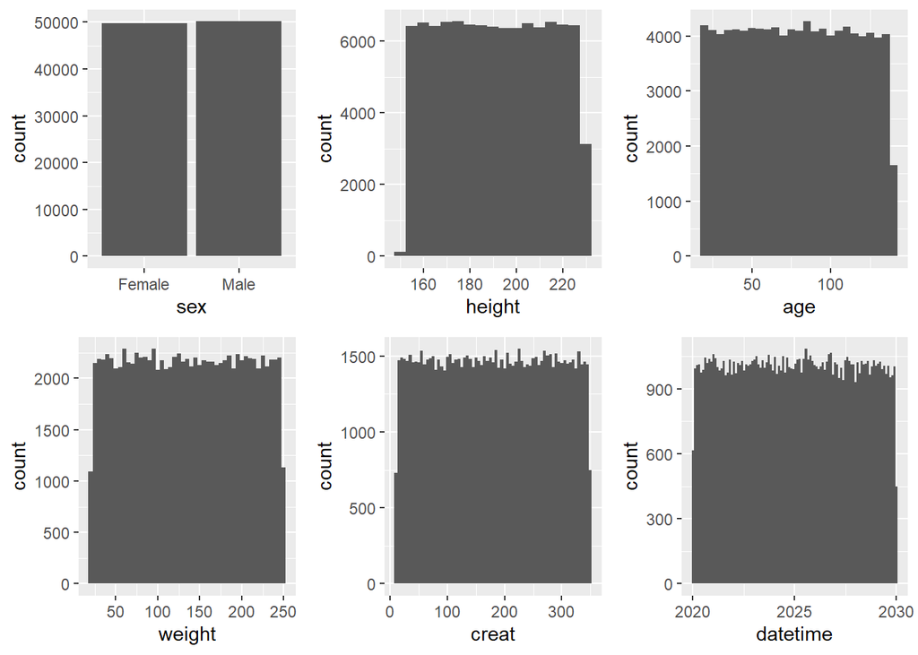

Figure 2.1: Distribution of simulated variables

## 2.2 Outputs

- Both the Excel and R calculators calculate the following:
  - `ibw` - ideal body weight
  - `ddw` - dose determining weight
  - `crcl` - creatinine clearance
  - `load_dose` - size of loading dose
  - `dose1` - size of maintenance dose 1
  - `dose2` - size of maintenance dose 2
  - `dose3` - size of maintenance dose 3
  - `dose4` - size of maintenance dose 4
  - `dose1_time` - date and time of maintenance dose 1
  - `dose2_time` - date and time of maintenance dose 2
  - `dose3_time` - date and time of maintenance dose 3
  - `dose4_time` - date and time of maintenance dose 4
  - `pre_level_before` - the maintenance dose that the pre-dose level should be taken at

# 3 Results

## 3.1 Do the two sets of results come from the same population?

- Both calculators have used the same inputs.

Table 3.1: Percentage match for input data

| data | id | sex | height | age | weight | creat | datetime |
| --- | --- | --- | --- | --- | --- | --- | --- |
| r with sim | 100 | 100 | 100 | 100 | 100 | 100 | 100 |
| excel with sim | 100 | 100 | 100 | 100 | 100 | 100 | 100 |
| r with excel | 100 | 100 | 100 | 100 | 100 | 100 | 100 |

## 3.2 Do the R and Excel outputs match?

- The calculators do not give the same results. Table 3.2 shows that the differences range in both size and frequency across the output variables.

Table 3.2: Comparison of R and Excel results

| Variable | Percentage | Count | Max abs diff |
| --- | --- | --- | --- |
| ibw | 0.125 | 125 | 0.001 |
| ddw | 0.021 | 21 | 0.001 |
| crcl | 0.000 | 0 | 0.000 |
| load_dose | 0.000 | 0 | 0.000 |
| dose1 | 1.714 | 1714 | 250.000 |
| dose2 | 1.714 | 1714 | 250.000 |
| dose3 | 1.714 | 1714 | 250.000 |
| dose4 | 1.714 | 1714 | 250.000 |
| dose1_time | 1.133 | 1133 | 24.000 |
| dose2_time | 1.133 | 1133 | 48.000 |
| dose3_time | 1.133 | 1133 | 72.000 |
| dose4_time | 1.133 | 1133 | 96.000 |
| pre_level_before | 54.209 | 54209 | 2.000 |

*Note.* Max abs diff = the maximum absoulute difference between results, where ‘absolute difference’ is the magitude of the diffference irrespective of the direction.

Table 3.3: Dosing ladder interpretations

| Dosing ladder | CrCl | Option 1 | Option 2 |
| --- | --- | --- | --- |
| 1 | >110 | >110 | >110.5 |
| 2 | 90-110 | 110 >= x > 90 | 110.5 >= x > 89.5 |
| 3 | 75-89 | 90 >= x > 75 | 89.5 >= x > 74.9 |

# 4 Modified R calculator

- In this section, I have made incremental changes to the R calculator to check the sources of discrepancies.

## 4.1 Modification 1 - CrCl boundary option 2

Table 4.1: Comparison of R and Excel results - Modification 1

| Variable | Percentage | Count | Max abs diff |
| --- | --- | --- | --- |
| dose1 | 0.000 | 0 | 0 |
| dose2 | 0.000 | 0 | 0 |
| dose3 | 0.000 | 0 | 0 |
| dose4 | 0.000 | 0 | 0 |
| dose1_time | 0.000 | 0 | 0 |
| dose2_time | 0.000 | 0 | 0 |
| dose3_time | 0.000 | 0 | 0 |
| dose4_time | 0.000 | 0 | 0 |
| pre_level_before | 53.737 | 53737 | 1 |

## 4.2 Modification 2 - Default pre-dose level

- Retaining modification 1 and making the default to take the pre-dose level before the third dose resolves the remaining discrepancies (Table 4.2).

Table 4.2: Comparison of R and Excel results - Modification 2

| Variable | Percentage | Count | Max abs diff |
| --- | --- | --- | --- |
| pre_level_before | 0 | 0 | 0 |

## 4.3 Summary

- There are discrepancies in the results provided by the R and Excel calculators.
- The substantive discrepancies are in the maintenance dose, the timing of the maintenance doses, and the suggested pre-dose level timing.
- These discrepancies are primarily the result of different interpretations of the dosing guidelines, which are possible due to vagueness in the guidelines. There are some minor discrepancies that result from rounding differences in the two software packages.
- Choosing which of the possible interpretations of the guidelines is beyond my knowledge and expertise, therefore I am unable to recommend one over the other, I am simply highlighting these choices and providing evidence for the scale of impact that these choices have.

# 5 Calculator v2

- This section refers to the `Vancomycin Dosing Calculator Calculator 4.4.xlsx` version of the calculator

Table 5.1: Comparison of R and Excel results

| Variable | Percentage | Count | Max abs diff |
| --- | --- | --- | --- |
| ibw | 0.125 | 125 | 0.001 |
| ddw | 0.021 | 21 | 0.001 |
| crcl | 0.000 | 0 | 0.000 |
| load_dose | 0.000 | 0 | 0.000 |
| dose1 | 1.714 | 1714 | 250.000 |
| dose2 | 1.714 | 1714 | 250.000 |
| dose3 | 1.714 | 1714 | 250.000 |
| dose4 | 1.714 | 1714 | 250.000 |
| dose1_time | 1.133 | 1133 | 24.000 |
| dose2_time | 1.133 | 1133 | 48.000 |
| dose3_time | 1.133 | 1133 | 72.000 |
| dose4_time | 1.133 | 1133 | 96.000 |
| pre_level_before | 0.472 | 472 | 2.000 |

*Note.* Max abs diff = the maximum absoulute difference between results, where ‘absolute difference’ is the magitude of the diffference irrespective of the direction.

- The original version of the Excel calculator was modified, such that the default for the pre-dose level was the second dose, rather than third dose, for those on step 6-8 of the dosing ladder and no modifications were made for working hours (given the dose schedule would be based on 24 or 48 hour increments). In addition, those on steps 1-5 of the ladder would have a pre-dose level taken at the third dose, unless that fell outside of working hours, in which case it was moved back to the fourth dose.
- The modification to the Excel calculator reduced the discrepancies in pre-dose level timing to 0.472%. As shown below, this discrepancy is due to the differences in CrCl boundaries used in the original R calculator.
- For those where there is a discrepancy, the Excel calculator suggests taking the pre-dose level later than the R calculator. In 244 (51.69%) of cases, this is at the fourth dose instead of the second, in the remainder, the Excel calculator suggests taking the pre-dose level at the third, instead of second, dose.

## 5.1 Modification 1 - CrCl boundaries

Table 5.2: Comparison of R and Excel results - Modification 1

| Variable | Percentage | Count | Max abs diff |
| --- | --- | --- | --- |
| dose1 | 0 | 0 | 0 |
| dose2 | 0 | 0 | 0 |
| dose3 | 0 | 0 | 0 |
| dose4 | 0 | 0 | 0 |
| dose1_time | 0 | 0 | 0 |
| dose2_time | 0 | 0 | 0 |
| dose3_time | 0 | 0 | 0 |
| dose4_time | 0 | 0 | 0 |
| pre_level_before | 0 | 0 | 0 |

## 5.2 Summary

Version 2 of the calculator (`Vancomycin Dosing Calculator Calculator 4.4.xlsx`) has fewer discrepancies with the R calculator than Version 1 did (`vancomycin_dosing_calculator_9.1.xlsx`). This is the result of changing the default pre-dose level to the earliest opportunity. Discrepancies resulting from the different interpretations of the boundaries for dosing ladder steps remain.